[figure not shown]

# Full Epic Array Quality Control

## Introduction

This is an R Markdown document for the Quality Control (QC) of Illumina EPIC microarray data of all the samples from the NIMHANS study.

Samples are not removed after each QC step, but a record is kept of samples which have already failed previous steps and the results of all tests are provided as output.

## Loading data

```
## [1] "Loading Mset: QC_nimhans/nimhans_Mset.rdat"
## [1] "Loaded Mset: QC_nimhans/nimhans_Mset.rdat"
```

```
## [1] "Loading RGset: QC_nimhans/nimhans_RGset.rdat"
```

### Study Information

**Study:** NIMHANS

**Array used:** Illumina EPIC microarray v1.0

**Date of QC:** 17 May 2022

**Sample ages:** 1, 88

**Sample Tissue:**

## QC Information

```
## [1] TRUE
## [1] "mSET and pheno samples match"
```

The phenotype file containing the sample information was loaded into R. Then the methylation data for the 96 samples were loaded into a methylumiset. This contains 0 NIMHANS and 0 fully methylated control samples.

## Check Signal Intensities

The intensity check is the biggest indicator of sample quality. The median methylated signal intensity and unmethylated signal intensity for each sample is calculcated.

A histogram and scatter plot of the resulting data are plotted to visualise the data quality. Samples are coloured by methylation plate or institute, to make sure there are no batch effects.

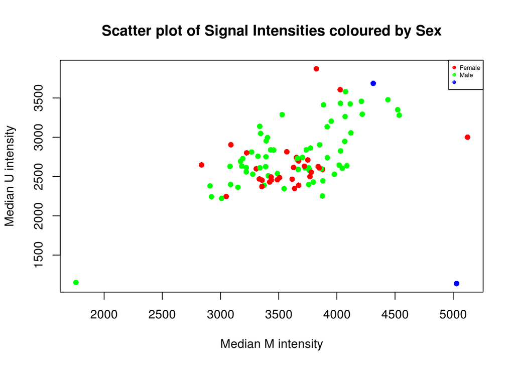

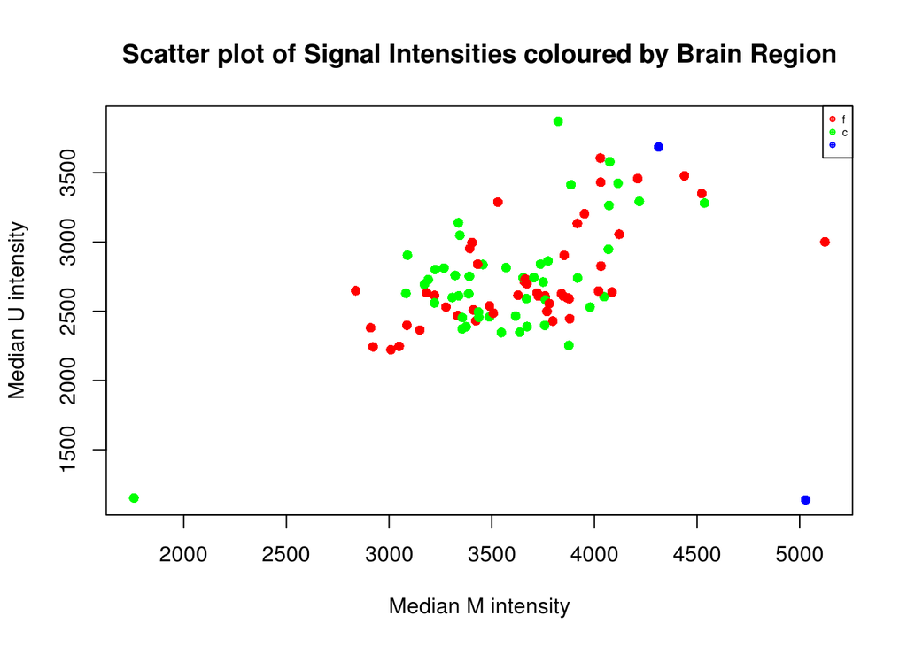

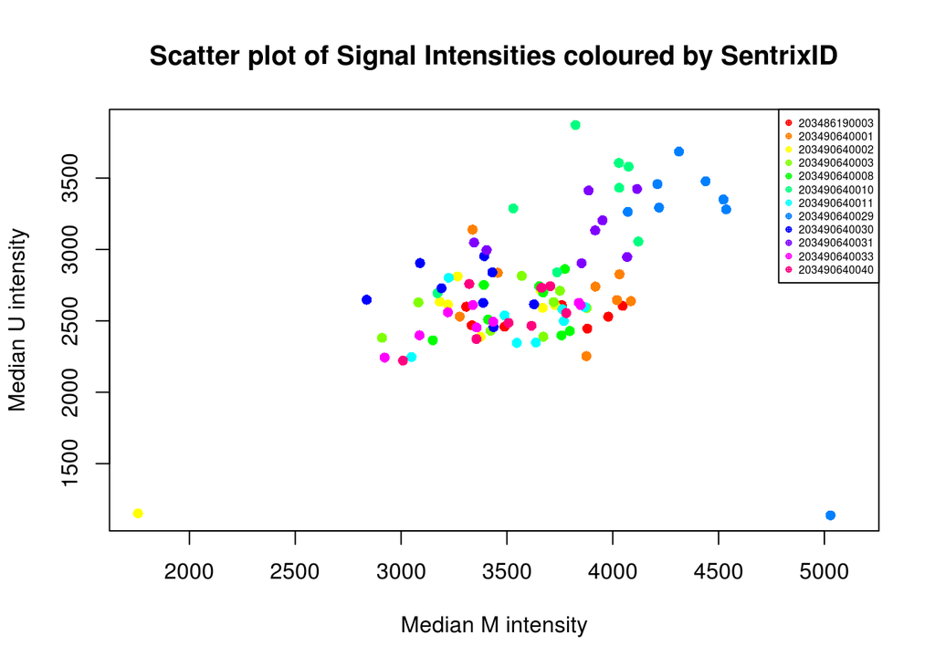

Samples with SentrixID 29 have higher M intensity

Although signal intensity is the largest predictor of sample quality, the threshold at which to exclude samples can vary from experiment to experiment - for example, signal intensities can vary slightly depending on tissue type or DNA extraction method. Samples which clearly deviate from the main cluster on the signal intensity plots should be removed.

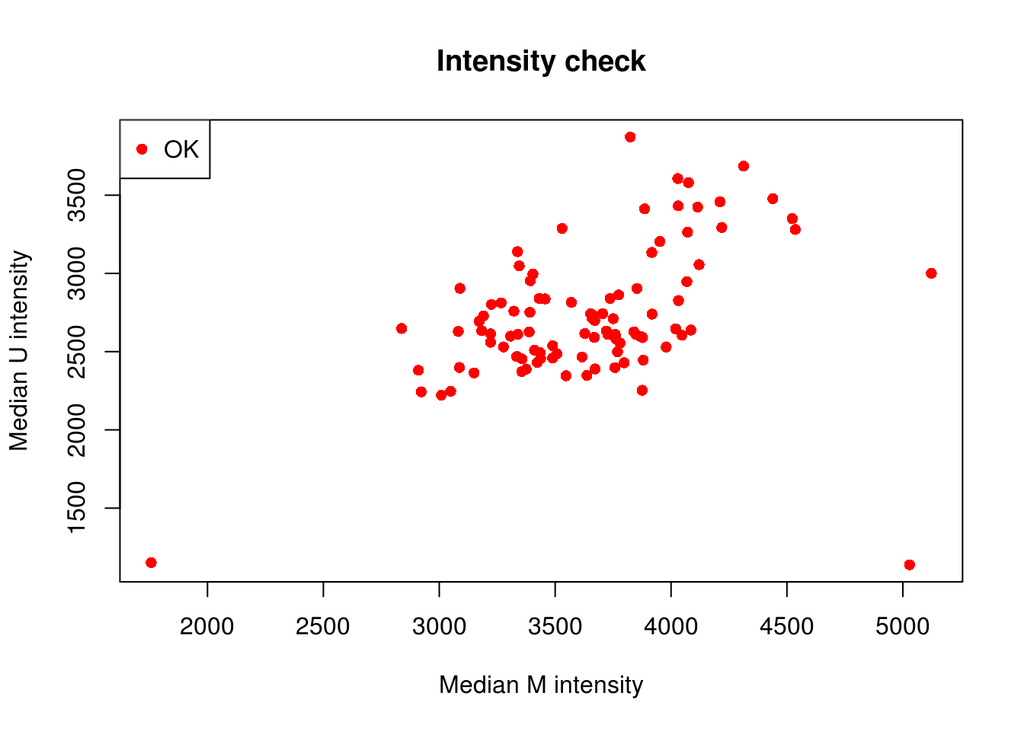

All signal intensities OK

```r
print(Stepsummary)
```

```
##                  Step1
## Failed This Step     0
## Total Failed         0
```

## Bisulphite Conversion

A bisulphite conversion statistic for each sample was calculated, and a histogram of the results plotted.

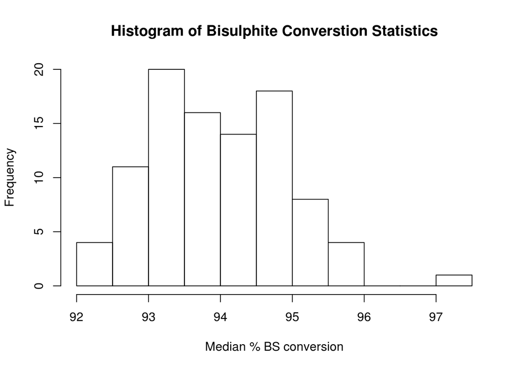

Samples with a conversion < 80% fail the QC, so with this threshold 0 samples fail the QC, and will be removed at a later stage.

```r
print(Stepsummary)
```

```
##                  Step1 Step2
## Failed This Step     0     0
## Total Failed         0     0
```

## Sex Check

A principal component analysis of the methylation data can be used to predict the sex of the samples.

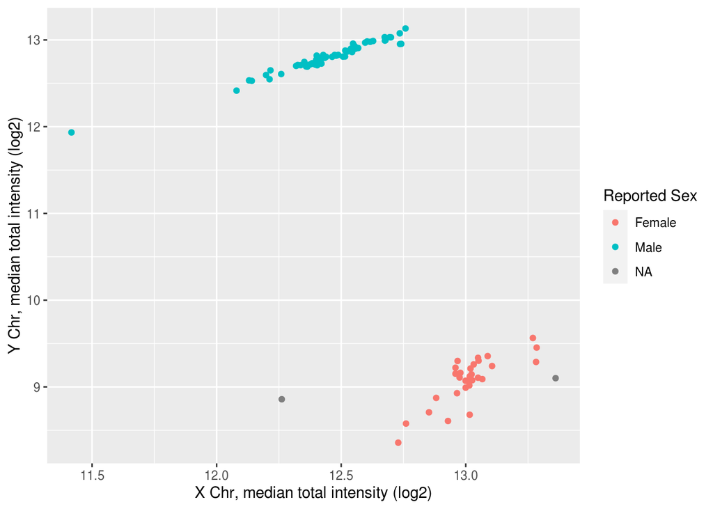

Here 2 number of sampless predicted sex does not match their reported sex. These samples fail the QC according to the findGenderPC function and, and will be removed.

```r
print(Stepsummary)
```

```
##                  Step1 Step2 Step3
## Failed This Step     0     0     2
## Total Failed         0     0     2
```

2 failed sex chack due to NA value. Cluster with females

## Genotype Sex Check

If there is SNP data available the reported sex will be comapred to the sex predicted using the SNP data and samples which do not match will be removed.

If SNP data is not available this step will be ignored.

## Check Genotypes

On the EPIC array there are 59 SNP probes. If have SNP data is present, we can compare the methylation on these SNP probes to the samples genotypes to confirm samples are from the expected individual.

If SNP data is not available this step will be ignored.

```
## [1] "No Genotype data to compare snps on DNAm array and SNP array"
```

Now we can check the correlation between the methylation and genotyped samples.

```r
print(Stepsummary)
```

```
##                  Step1 Step2 Step3
## Failed This Step     0     0     2
## Total Failed         0     0     2
```

## Genetic correlations

The 59 SNP probes on the array can also be used to estimate genetic correlations between samples.

This small number of probes means that only identical samples (such as samples from the same individual, MZ twins, individual brainIDs or samples duplicated by error) can be identified and no lower proportion of genetic relatedness (such as siblings) can be inferred.

If your study is not a paired design this step will be skipped

### Checking samples from unrelated individuals

This study design assumes that each sample is completely unqiue and that there should be no duplicates with any other sample. The SNPs on the DNAm array can be used to predicted that no sample correlates with another. For each sample, we can find its maximum correlation with any other sample, and plot a histogram of the results. Any samples with a threshold greater than 0.8 indicates that they are duplicates.

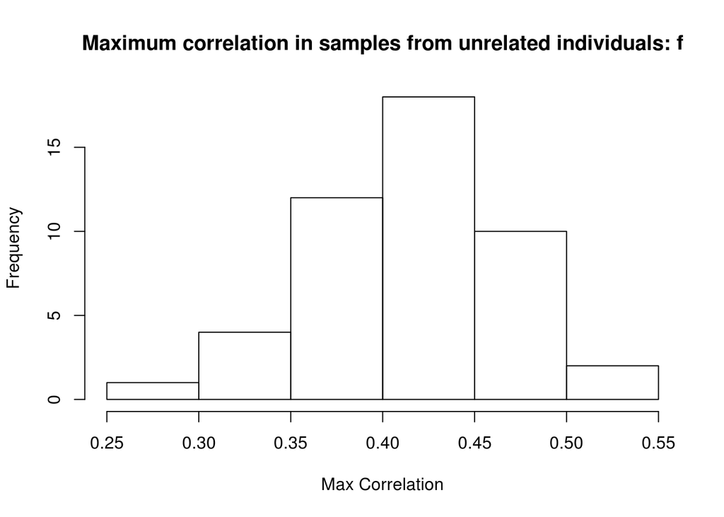

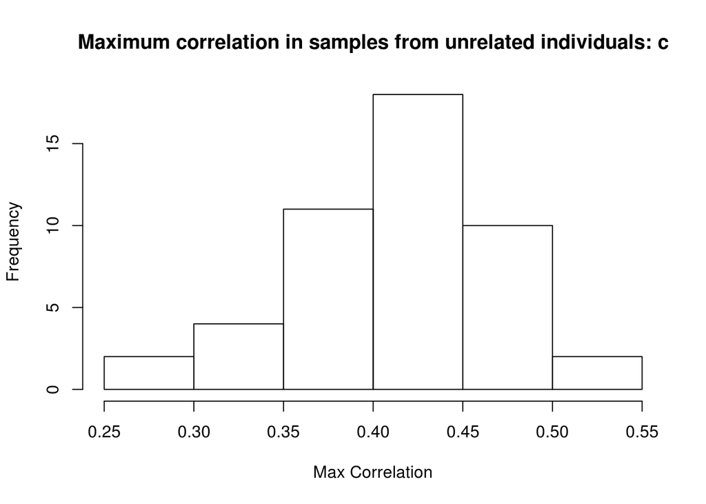

[figure not shown]

0 samples have a maximum correlation > 0.8 with another unrelated sample.

Sometimes samples are duplicates and we can check that there is also duplicates in the genotype data if necessary.

```r
# print(Stepsummary)
```

## Age Prediction

The age of samples can be predicted from their methylation data using Horvath's Coefficients and compared to the samples' reported ages.

However, this can be inaccurate and so it is used as a quality check and not as a reason to remove samples. Therefore, the following plot only contains samples which have passed the previous QC steps.

```
## No coefficients detected, using Horvaths clock
```

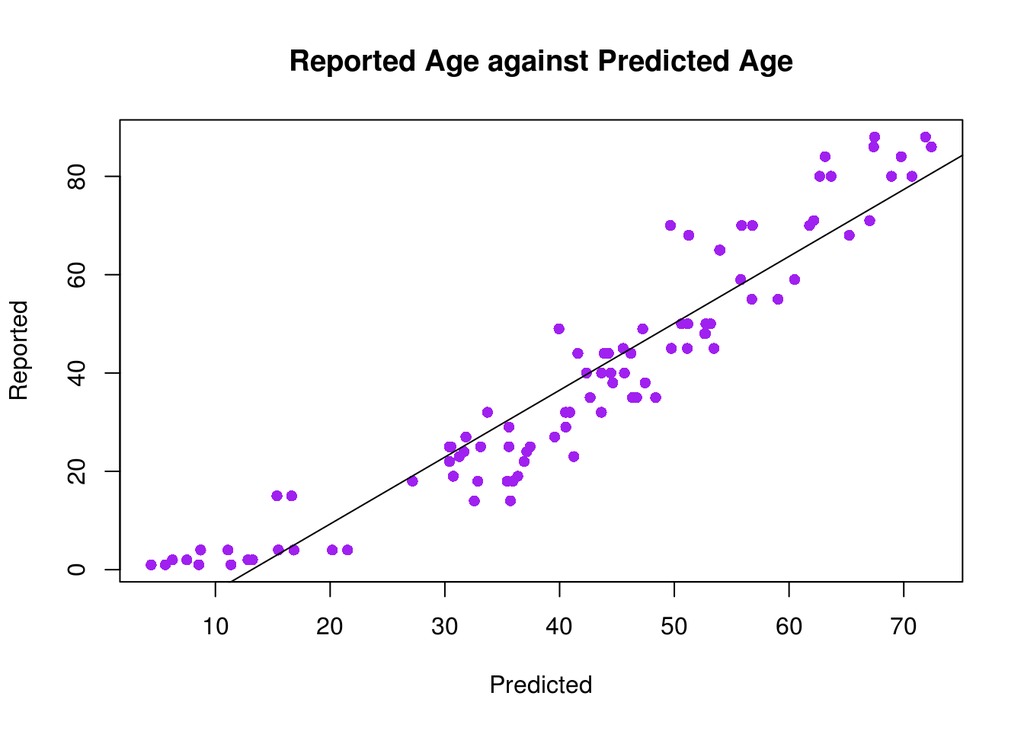

We can see there is a correlation between predicted and reported ages in the samples 0.9448842. Generally, Horvath's clock doesn't predict as well in older and brain samples. The predicted ages are added to the QC output.

## Smoking Score

Smoking has well known associations with DNA methylation at sites across the genome. Using a method developed by Elliot et al. 2014 we can calculate a smoking score based on DNA methylation at these known sites, to predict smoking status.

A smoking score is calculated for each sample and a histogram of the scores is plotted below. This score is most accurate in blood and bucal samples and is less accurate in brain tissue.

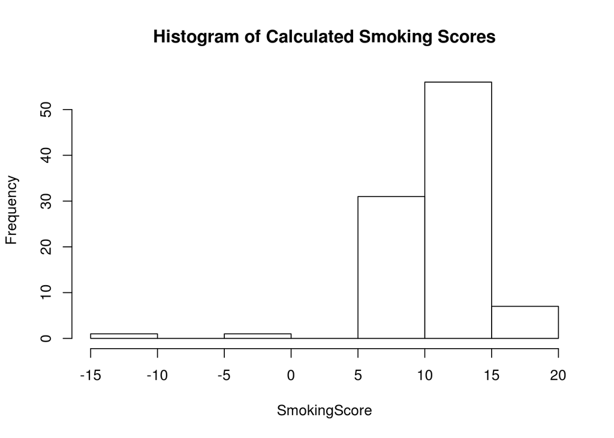

## Tissue Prediction

Only differentiates blood, buccal and saliva

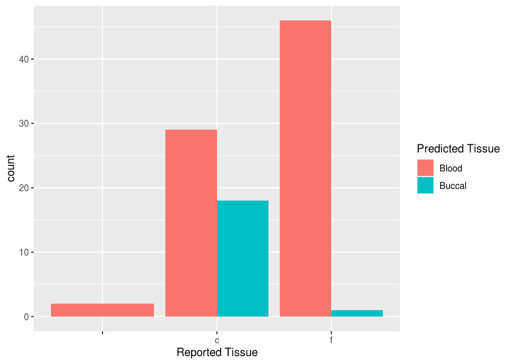

## Pfilter

The pfilter function in the wateRmelon package filters data sets based on beadcounts and detection p-values.

### Beadcounts

If the percentage of samples with a beadcount less than 3 is greater than 5% for any probe, the probe is removed.

### Detection p-values

```
## 0 samples having 1 % of sites with a detection p-value greater than 0.05 were removed
## Samples removed:
## 3278 sites were removed as beadcount <3 in 5 % of samples
## 5099 sites having 1 % of samples with a detection p-value greater than 0.05 were removed
```

0 out of 96 samples fail the pfilter with these thresholds.

```r
print(Stepsummary)
```

```
##                  Step1 Step2 Step3 Step7
## Failed This Step     0     0     2     0
## Total Failed         0     0     2     2
```

## Outliers

The outlyx function in the wateRmelon package can be used to check if any of the remaining samples are classed as 'outliers' and should also be removed prior to normalisation.

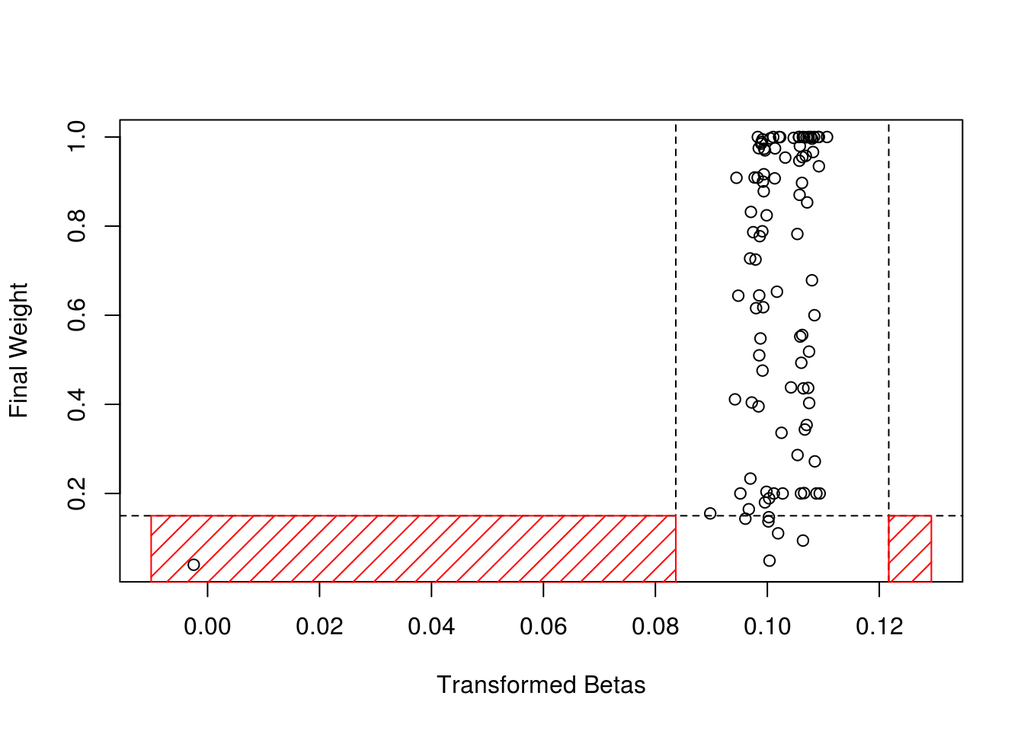

```r
print(Stepsummary)
```

```
##                  Step1 Step2 Step3 Step7 Step8
## Failed This Step     0     0     2     0     1
## Total Failed         0     0     2     2     2
```

## Normalisation

The methylation data for just the passed samples and probes is quantile normalised using the dasen function from the wateRmelon package.

The 'qual' function in the wateRmelon package can be used to assess the degree of difference between normalised and raw betas

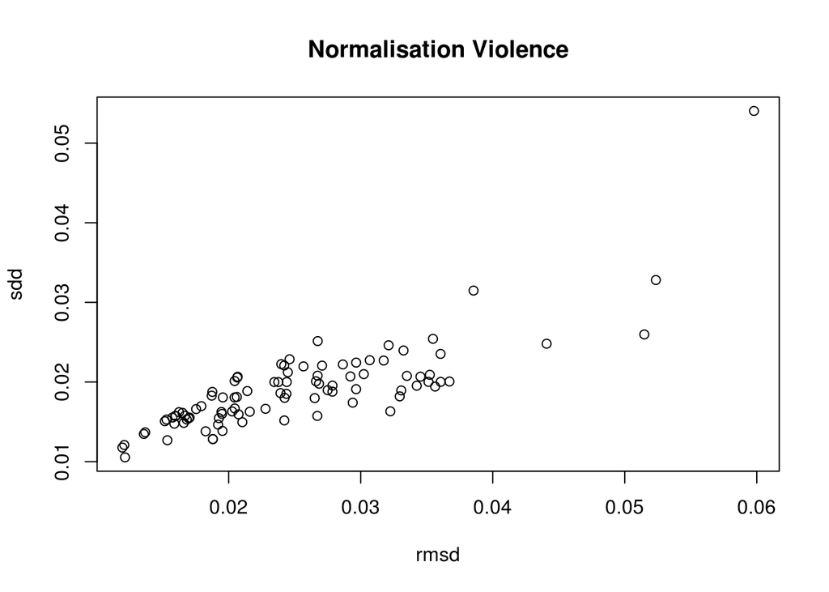

```
## [1] FALSE
```

```r
print(Stepsummary)
```

```
##                  Step1 Step2 Step3 Step7 Step8 Step9
## Failed This Step     0     0     2     0     1     0
## Total Failed         0     0     2     2     2     2
```

Density plots of the beta values are plotted for each sample before and after normalisation below (separated by type I and type II probes). Samples with high normalisation violence will be removed.

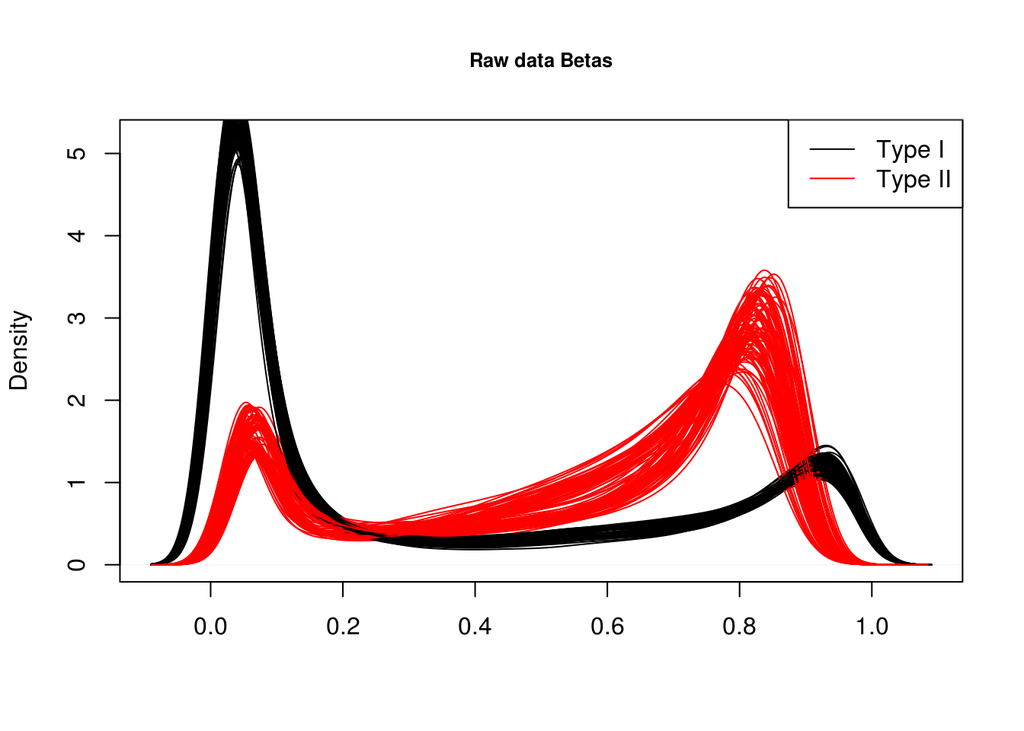

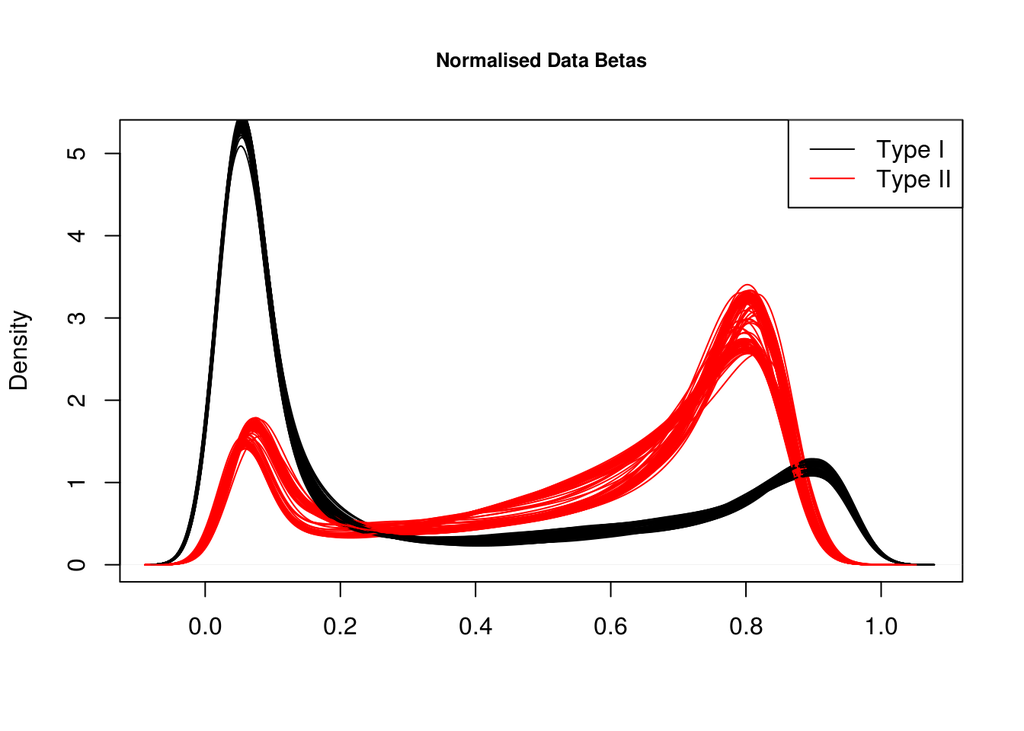

The distributions generally look as we would expect, and dasen has not caused any samples to have beta values outside the expected 0-1 range.

There should be no points failing the second normalisation step as they will have been removed previously

## Cell Composition

DNA methylation varies between different cell types, and so the composition of cell types can significantly affect the methylation of samples. Therefore, estimations of cell-type composition is an important variable to consider when analysing this type of data.In order to estimate the blood cell proportions, we use an function estimateCellCounts in the R package Minfi, developed by Hansen et al. We will estimate cell types CD8T, CD4T, Bcells, Granulocytes, Monocytes and NK cells. Samples that have failed until this stage will not be included in calculated cell proportions.

If your tissue is not blood, there is currently no appropriate algorithm to calculate you cell propotions for your tissue of interest. Therefore, this part of the report will not be run and we will move along to the next part of the report.

The estimated cell proportions are added to the QC output and can be used as covariates in later analyses.

## QC Summary

The QC results for the 2 failed samples and 94 passed samples are saved to QC_nimhans/SamplesFailedQC.csv and QC_nimhans/SamplesPassedQC.csv respectively.

SNP probes, probes containing common SNPs, and probes with non-specific binding are removed at this stage to prevent technical artifacts influencing the results in later analyses.

Finally the QCed, normalised and filtered dataset is saved to QC_nimhans/nimhans_Normalised.rdat ready for subsequent analysis.

The final dataset contains 94 samples and 805755 probes.

[figure not shown]